# Normalization Comparison

D. Ford Hannum

2023-07-05

# 1 Introduction

This file accompanies the Vizgen Analysis Guides: Normalzation.

Here we will compare three normalization methods.

1. Standard (Std)
2. Seurat SCTransform (SCT)
3. Spatial (Spat)

We chose to run this notebook in R, because of the use of a SCTransform function, which is from the Seurat package which is written in R.

# 2 Loading packages

```r
knitr::opts_chunk$set(echo = TRUE)
library(Seurat) # to run normalizaiton methods
```

```r
library(data.table) # data processing library
library(ggplot2) # package to make visualizaitons
```

# 3 Loading Data

Here we are going to use publicly available data from a MERSCOPE mouse brain sample.

For our purposes we only need cell_by_gene.csv and cell_metadata.csv files.

```r
md <- fread('https://vzg-vzg-showcase-data.s3.amazonaws.com/Mouse_Brain_Showcase_232/Slice-1_Replicate-1/cell_metadata.csv',
               header = T, data.table = FALSE)

counts <- fread('https://vzg-vzg-showcase-data.s3.amazonaws.com/Mouse_Brain_Showcase_232/Slice-1_Replicate-1/cell_by_gene.csv',
               header = T, data.table = FALSE)

rownames(md) <- md$EntityID
rownames(counts) <- counts$cell
counts <- counts[,-1] # removing cells as a column so we have a data frame of only counts
blanks <- counts[,grepl('Blank', colnames(counts))] # saving blanks
counts <- counts[,!grepl('Blank', colnames(counts))] # removing blanks

counts <- t(counts)

# counts[1:5,1:5]
table(rownames(md) == colnames(counts)) # making sure the data frames align
```

```
##
##  TRUE
## 78273
```

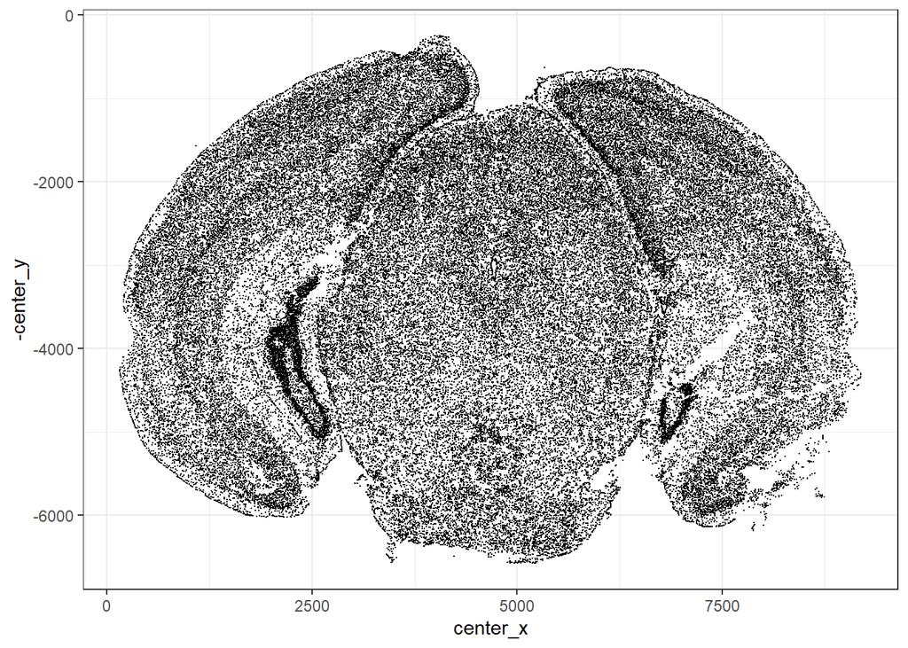

```r
ggplot(md, aes(x = center_x, y = -center_y)) +
  geom_point(size = .1) + theme_bw()
```

# 4 Seurat Workflow

Using Seurat we will do some basic filtering.

```r
spat <- CreateSeuratObject(counts = counts,
                           assay = 'RNA',
                           meta.data = md)

# spat
```

## 4.1 Filtering

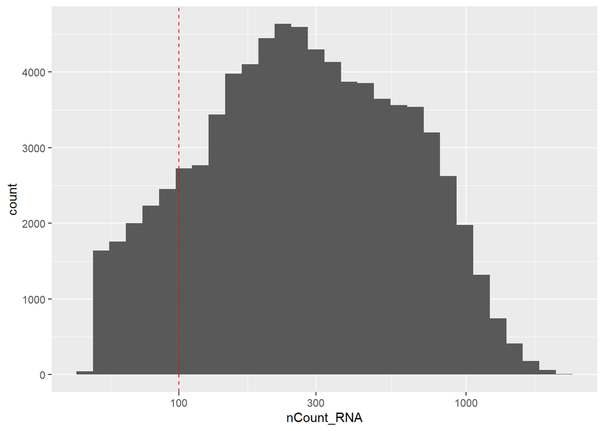

```r
ggplot(spat@meta.data, aes(x = nCount_RNA)) +
  geom_histogram() +
  scale_x_log10() +
  geom_vline(xintercept = 100, linetype = 2, colour = 'red')
```

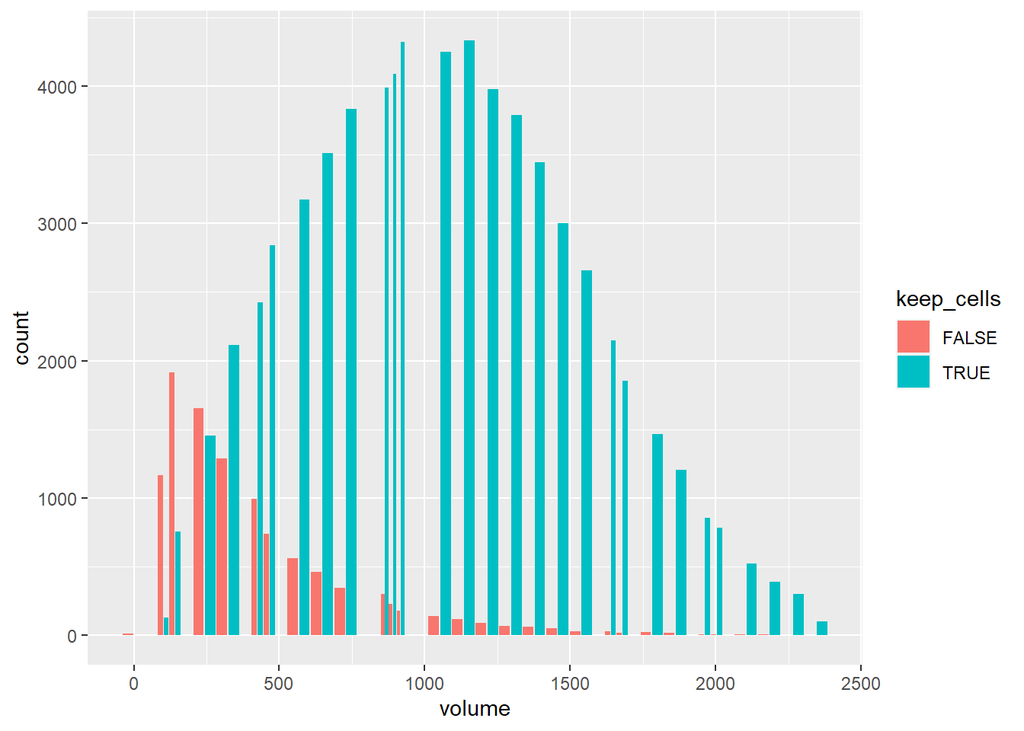

```r
spat$keep_cells <- spat$nCount_RNA >= 100

ggplot(spat@meta.data, aes(x = volume, fill = keep_cells)) +
  geom_histogram(position = position_dodge2())
```

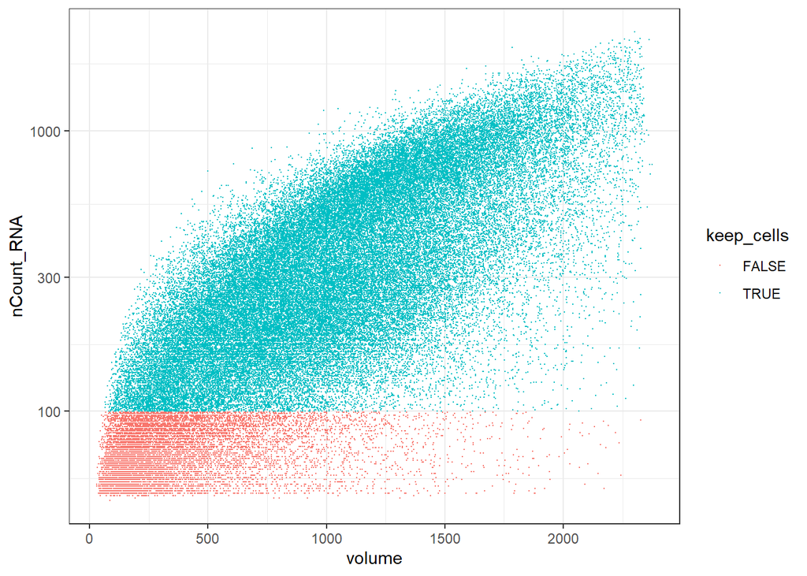

```r
ggplot(spat@meta.data, aes(x = volume, y = nCount_RNA,
                           colour = keep_cells)) +
  geom_point(size = .1) +
  theme_bw() +
  scale_y_log10()
```

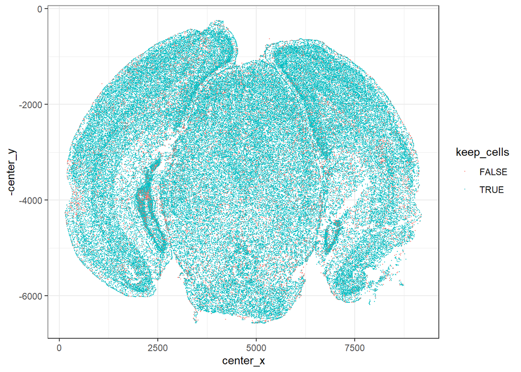

```r
ggplot(spat@meta.data, aes(x = center_x, y = -center_y,
                           colour = keep_cells)) +
  geom_point(size = .1) +
  theme_bw()
```

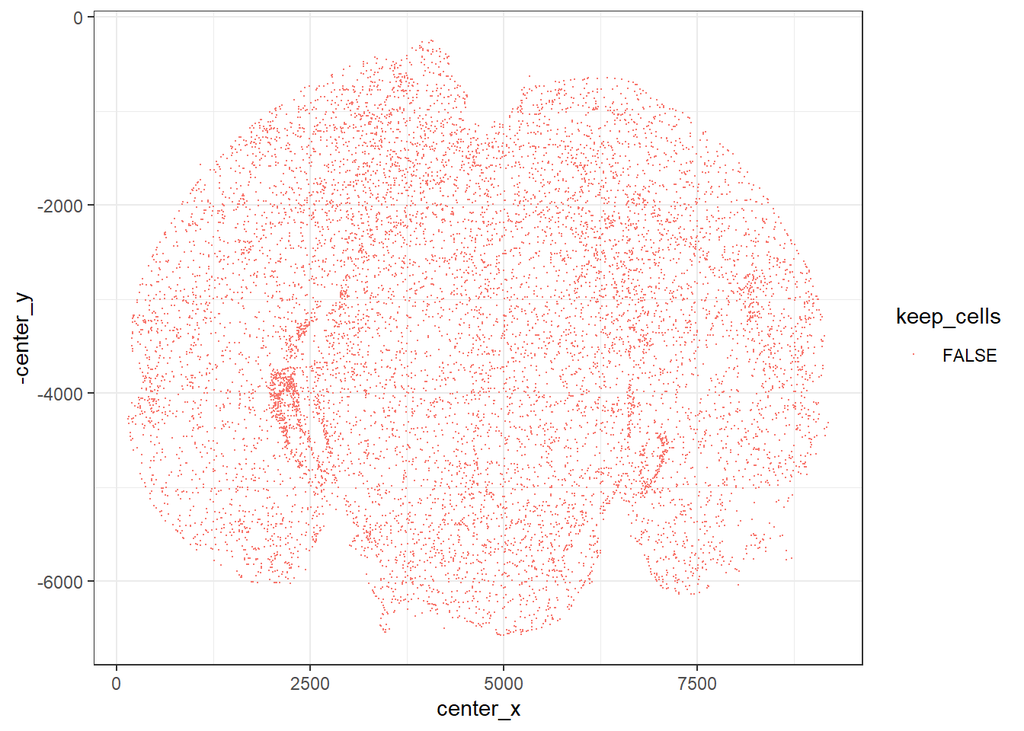

```r
ggplot(spat@meta.data[spat$keep_cells == FALSE,], aes(x = center_x, y = -center_y,
                           colour = keep_cells)) +
  geom_point(size = .1) +
  theme_bw()
```

We see that the distribution of cells that don’t pass filtering seems to be relatively evenly distributed throughout the tissue. Therefore our filtering isn’t biasing against a particular area of the brain.

There is a more dense area of cells filtered out on the middle-left of the tissue, but that area is also more dense for cells that pass filtering (in general just a more cellular dense area of the tissue)

```r
spat <- subset(spat, nCount_RNA >= 100)
```

# 5 Normalizations

## 5.1 Standard (Std)

```r
spat <- NormalizeData(spat, normalization.method = 'LogNormalize',
                      scale.factor =  1e4, verbose = F)
spat <- ScaleData(spat, features = rownames(spat), verbose = F)

spat <- RunPCA(spat, features = rownames(spat), verbose = FALSE)

spat <- FindNeighbors(spat, dims = 1:10, verbose = F)

spat <- FindClusters(spat, resolution = .5, verbose = F)

spat <- RunUMAP(spat, dims = 1:10, verbose = F)
spat@meta.data[,paste0('Std_pca',1:5)] <- spat@reductions$pca@cell.embeddings[,1:5]
spat@meta.data[,paste0('Std_umap',1:2)] <- spat@reductions$umap@cell.embeddings
```

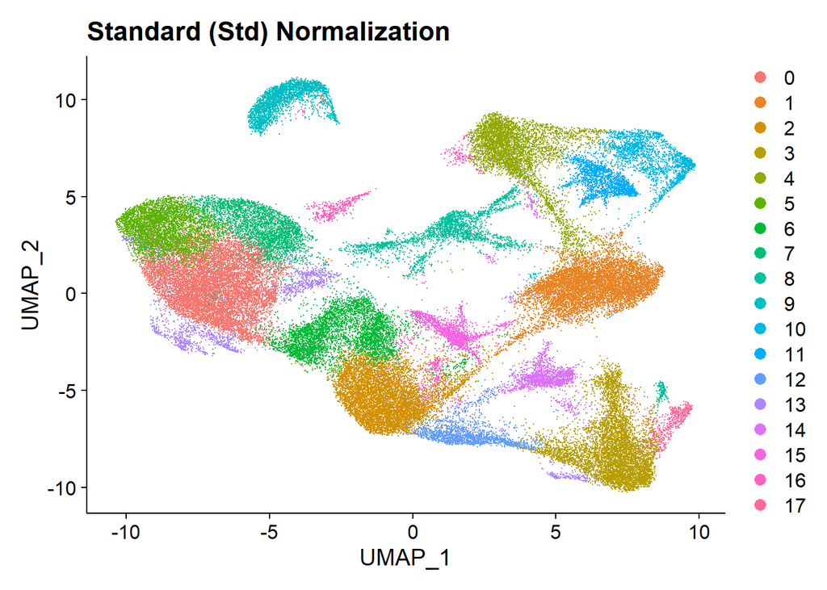

```r
DimPlot(spat) + ggtitle('Standard (Std) Normalization')
```

## 5.2 SCTransform (SCT)

```r
spat <- SCTransform(spat, clip.range = c(-10,10), vars.to.regress = 'volume',
                    verbose = F)

spat <- RunPCA(spat, features = rownames(spat), verbose = FALSE)

spat <- FindNeighbors(spat, dims = 1:10, verbose = F)

spat <- FindClusters(spat, resolution = .5, verbose = F)

spat <- RunUMAP(spat, dims = 1:10, verbose = F)
spat@meta.data[,paste0('sct_pca',1:5)] <- spat@reductions$pca@cell.embeddings[,1:5]
spat@meta.data[,paste0('sct_umap',1:2)] <- spat@reductions$umap@cell.embeddings
```

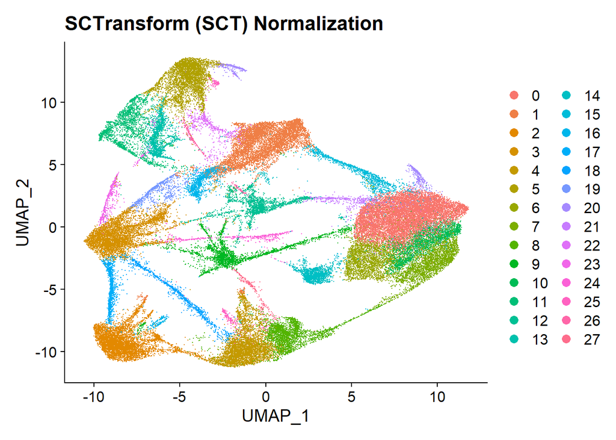

```r
DimPlot(spat) + ggtitle('SCTransform (SCT) Normalization')
```

## 5.3 Spatial (Spat)

Normalization by volume (transcipts per volume (Spat)) will happen outside of Seurat then we will add the data back into Seurat in a new assay. We will divide the counts by the volume and then scale it back to the median volume for all cells (1034).

```r
scale.factor = median(spat$volume)
transcripts_per_volume <- function(x){
  x[1:483] /x[484] * scale.factor
}

# w <- apply(p,2,transcripts_per_volume)
# tail(w)
```

```r
spat[['tpv']] <- spat@assays$RNA
DefaultAssay(spat) <- 'tpv'

tpv <- spat@assays$RNA@counts

tpv <- rbind(tpv,spat$volume)
tpv <- apply(tpv,2,transcripts_per_volume)
spat@assays$tpv@data <- tpv
spat <- ScaleData(spat, features = rownames(spat), verbose = F)

spat <- RunPCA(spat, features = rownames(spat), verbose = FALSE)

spat <- FindNeighbors(spat, dims = 1:10, verbose = F)

spat <- FindClusters(spat, resolution = .5, verbose = F)

spat <- RunUMAP(spat, dims = 1:10, verbose = F)

spat@meta.data[,paste0('tpv_pca',1:5)] <- spat@reductions$pca@cell.embeddings[,1:5]
spat@meta.data[,paste0('tpv_umap',1:2)] <- spat@reductions$umap@cell.embeddings
```

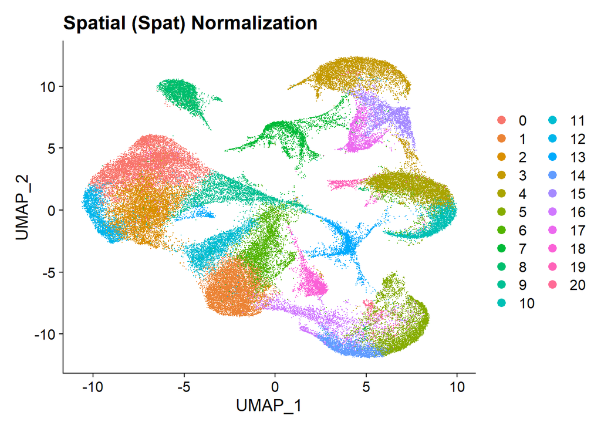

```r
DimPlot(spat) + ggtitle('Spatial (Spat) Normalization')
```

# 6 Density

Looking at the density of the cells. The “standard” methods adjust for library size, but the Spat (transcripts by volume) method commonly used in FISH data adjusts for volume.

Here we want to see how similar volume and library size are, and base on the figure below there is a high positive correlation between the two.

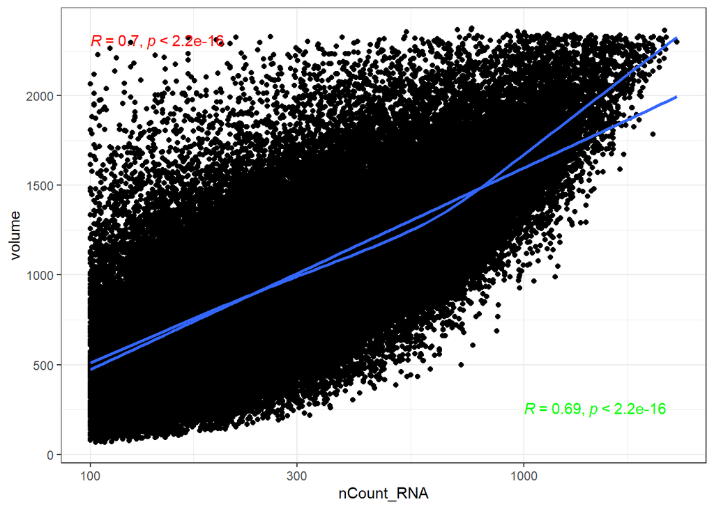

```r
ggplot(spat@meta.data, aes(x = nCount_RNA, y = volume)) +
  geom_point() +
  geom_smooth(method = 'lm', se = F) +
  geom_smooth(se = F) +
  ggpubr::stat_cor(colour = 'red') +
  ggpubr::stat_cor(colour = 'green',label.x = 3, label.y = 250,
                   method = 'spearman') +
  theme_bw() +
  scale_x_log10()
```

# 7 Correlation

Here we will look at the pearson correlation for each cell between the three different normalizations (leading to three pairwise comparisons). High correlation indicates a strong similarity between the normalization methods. We will look at the correlations for the entire data, and also by clusters (which were calculated for each normalization method).

```r
x <- spat@assays$RNA@scale.data
y <- spat@assays$tpv@scale.data

cor_list <- c()
for (i in 1:dim(x)[2]){
  # if (i %% 500 == 0){print(paste0(i,' out of ',dim(x)[2]))}
  cor_list <- c(cor_list,cor(x[,i],y[,i], method = 'pearson'))
}

spat$cor_tpv_std <- cor_list
```

```r
x <- spat@assays$SCT@scale.data
y <- spat@assays$tpv@scale.data[rownames(x),]

cor_list <- c()
for (i in 1:dim(x)[2]){
  # if (i %% 500 == 0){print(paste0(i,' out of ',dim(x)[2]))}
  cor_list <- c(cor_list,cor(x[,i],y[,i], method = 'pearson'))
}

spat$cor_tpv_sct <- cor_list
```

```r
x <- spat@assays$SCT@scale.data
y <- spat@assays$RNA@scale.data[rownames(x),]

cor_list <- c()
for (i in 1:dim(x)[2]){
  # if (i %% 500 == 0){print(paste0(i,' out of ',dim(x)[2]))}
  cor_list <- c(cor_list,cor(x[,i],y[,i], method = 'pearson'))
}

spat$cor_RNA_sct <- cor_list
```

## 7.1 Plots

### 7.1.1 Std vs Spat

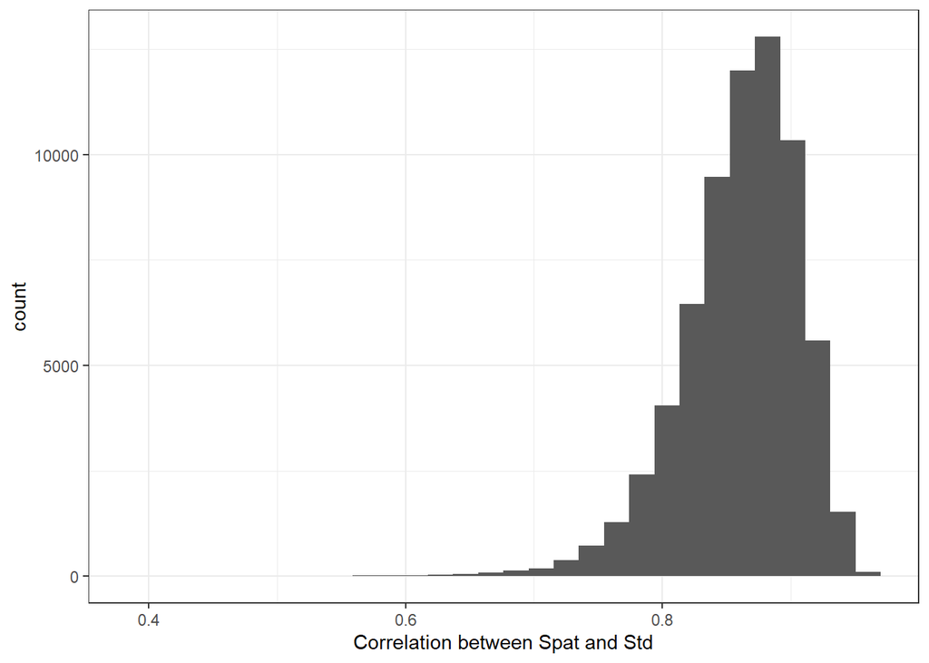

```r
ggplot(spat@meta.data, aes(x = cor_tpv_std)) +
  geom_histogram() +
  theme_bw() +
  xlab('Correlation between Spat and Std')
```

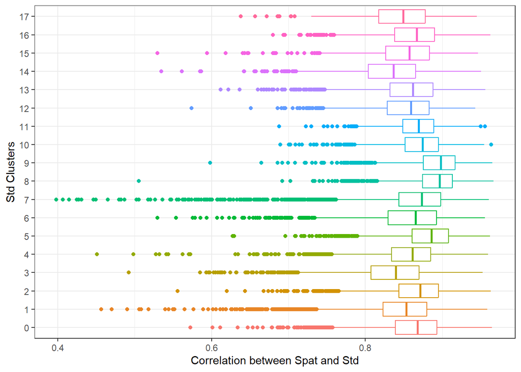

```r
ggplot(spat@meta.data, aes(x = cor_tpv_std, y = RNA_snn_res.0.5,
                           colour = RNA_snn_res.0.5)) +
  geom_boxplot() +
  theme_bw() +
  theme(legend.position = 'none') +
  ylab('Std Clusters') +
  xlab('Correlation between Spat and Std')
```

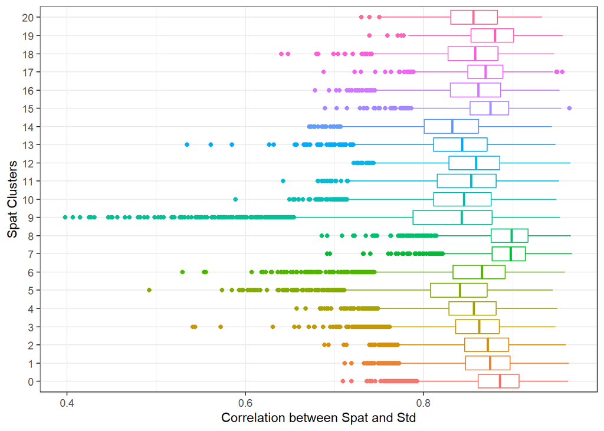

```r
ggplot(spat@meta.data, aes(x = cor_tpv_std, y = tpv_snn_res.0.5,
                           colour = tpv_snn_res.0.5)) +
  geom_boxplot() +
  ylab('Spat Clusters') +
  theme_bw() +
  theme(legend.position = 'none') +
  xlab('Correlation between Spat and Std')
```

We see that there is a high correlation between the Std and Spat normalizations, and all clusters seem to have a similar correlation.

### 7.1.2 Std vs SCT

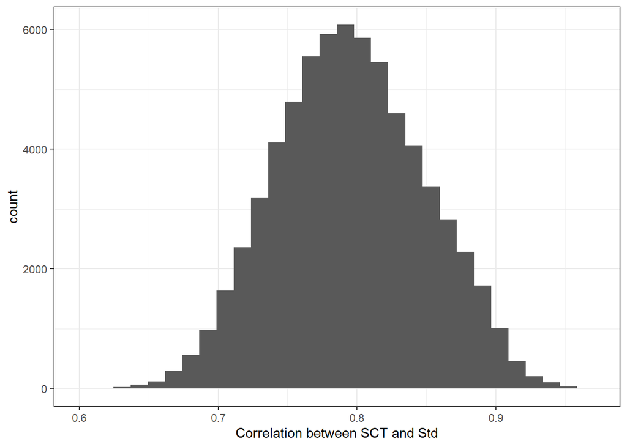

```r
ggplot(spat@meta.data, aes(x = cor_RNA_sct)) +
  geom_histogram() +
  theme_bw() +
  xlab('Correlation between SCT and Std')
```

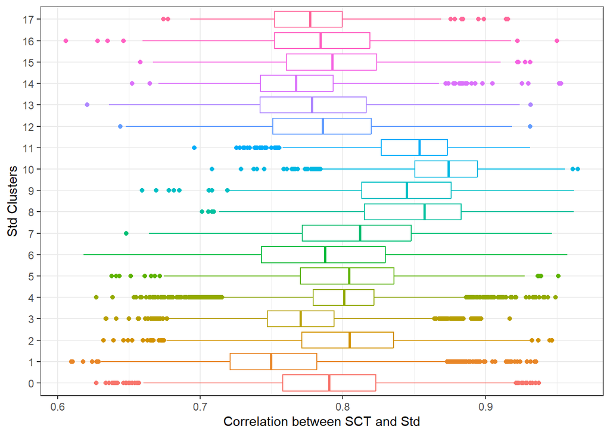

```r
ggplot(spat@meta.data, aes(x = cor_RNA_sct, y = RNA_snn_res.0.5,
                           colour = RNA_snn_res.0.5)) +
  geom_boxplot() +
  theme_bw() +
  theme(legend.position = 'none') +
  ylab('Std Clusters') +
  xlab('Correlation between SCT and Std')
```

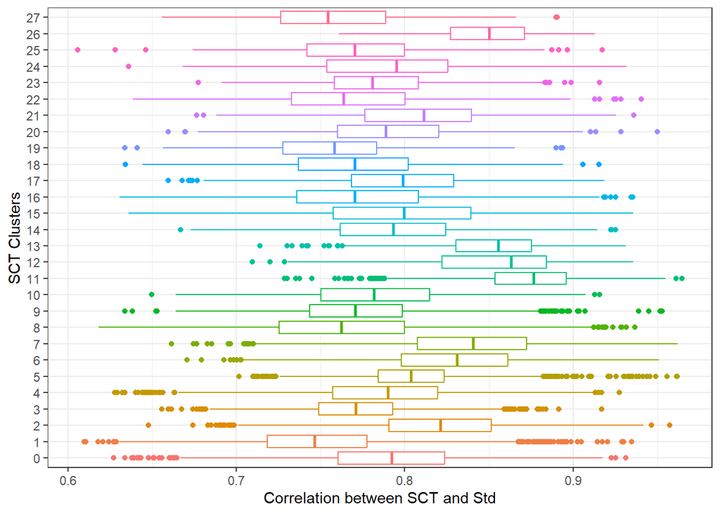

```r
ggplot(spat@meta.data, aes(x = cor_RNA_sct, y = SCT_snn_res.0.5,
                           colour = SCT_snn_res.0.5)) +
  geom_boxplot() +
  ylab('SCT Clusters') +
  theme_bw() +
  theme(legend.position = 'none') +
  xlab('Correlation between SCT and Std')
```

We see a slightly lower correlation for Std vs SCT compared to Std vs Spat, but still a significant positive correlation that isn’t biased towards certain clusters.

### 7.1.3 Spat vs SCT

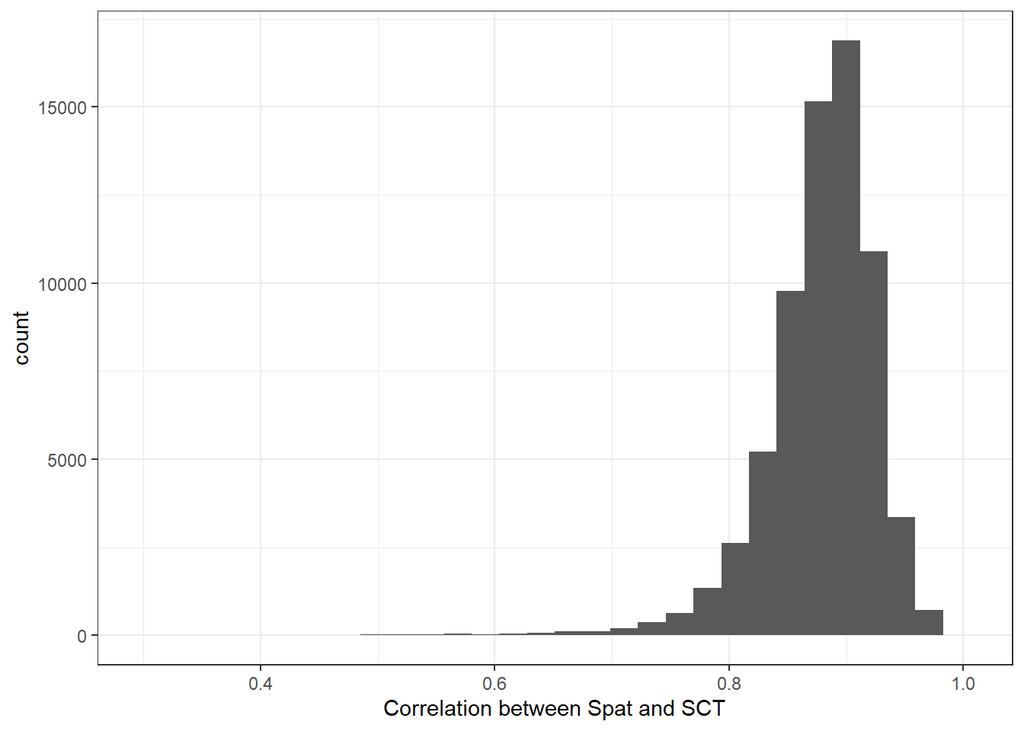

```r
ggplot(spat@meta.data, aes(x = cor_tpv_sct)) +
  geom_histogram() +
  theme_bw() +
  xlab('Correlation between Spat and SCT')
```

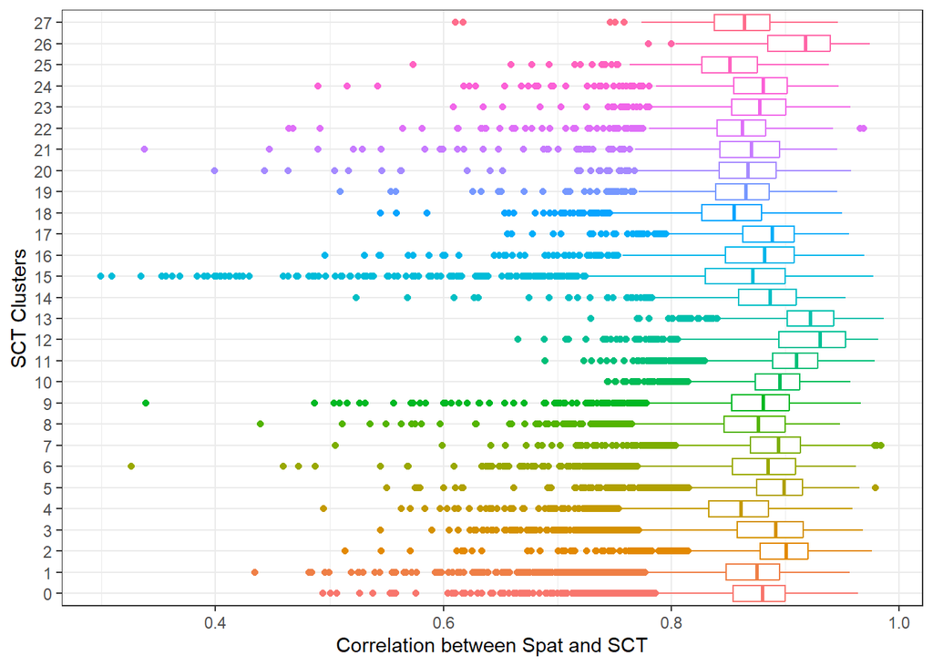

```r
ggplot(spat@meta.data, aes(x = cor_tpv_sct, y = SCT_snn_res.0.5,
                           colour = SCT_snn_res.0.5)) +
  geom_boxplot() +
  theme_bw() +
  theme(legend.position = 'none') +
  ylab('SCT Clusters') +
  xlab('Correlation between Spat and SCT')
```

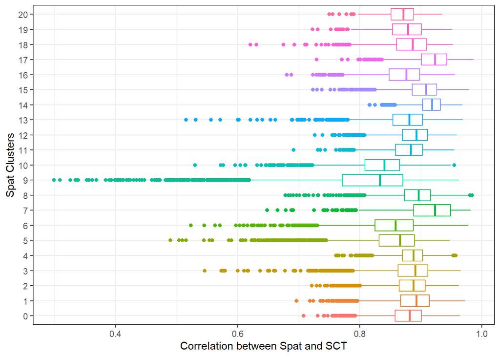

```r
ggplot(spat@meta.data, aes(x = cor_tpv_sct, y = tpv_snn_res.0.5,
                           colour = tpv_snn_res.0.5)) +
  geom_boxplot() +
  ylab('Spat Clusters') +
  theme_bw() +
  theme(legend.position = 'none') +
  xlab('Correlation between Spat and SCT')
```

Here we see the highest correlation between any two normalization methods

## 7.2 Conclusions

All in all we see a strong correlation between the scaled data from all three normalization methods. The small differences between the normalization methods may change downstream analyses, but overall shouldn’t effect most of them.

# 8 Cluster Comparison

## 8.1 Cross-Tabulation

We are going to compare the cross-tabulation of the clusters for each cell. If the differences in normalization methods is small we will see relatively direct correspondences between clusters. The correspondence may not be 1-to-1, because the number of clusters varies per method.

### 8.1.1 Std vs Spat

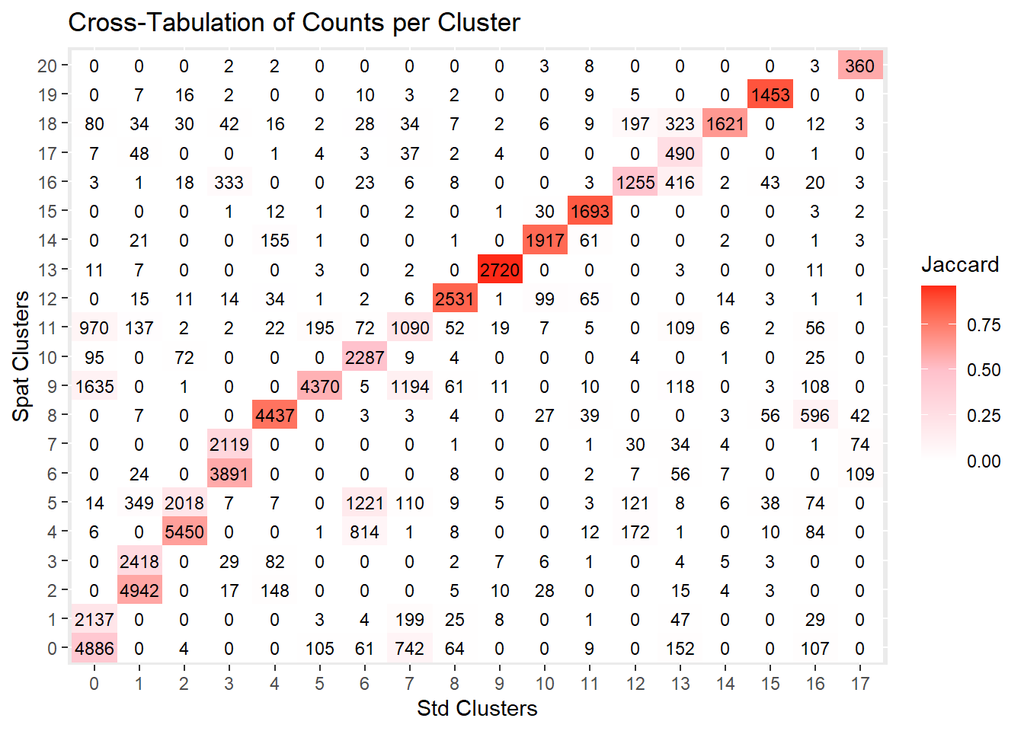

```r
x <- as.data.frame(table(spat$RNA_snn_res.0.5, spat$tpv_snn_res.0.5))

tpv_cluster <- c()
counts_ <- c()
for (i in unique(x$Var2)){
  temp <- x[x$Var2 == i,]
  cluster <- as.character(temp[which.max(temp$Freq),]$Var1)
  count <- temp[which.max(temp$Freq),]$Freq
  tpv_cluster <- c(tpv_cluster, cluster)
  counts_ <- c(counts_, count)
}

clusters <- data.frame(row.names = unique(x$Var2),
           counts = counts_,
           tpv_cluster = as.numeric(tpv_cluster))
clusters <- clusters[order(clusters$tpv_cluster, -clusters$counts),]
clusters$clusters <- 0:(dim(clusters)[1] -1)

# levels(spat$tpv_snn_res.0.5)
spat$tpv_snn_res.0.5_renamed <- factor(spat$tpv_snn_res.0.5,
                                       labels = clusters[paste0(0:20),]$clusters)
spat$tpv_snn_res.0.5_renamed <- factor(spat$tpv_snn_res.0.5_renamed,
                                       levels = 0:20)

x <- as.data.frame(table(spat$RNA_snn_res.0.5, spat$tpv_snn_res.0.5_renamed))


x$Var1.sum <- NA

for (i in unique(x$Var1)){
  x[x$Var1 == i,]$Var1.sum <- sum(x[x$Var1 == i,]$Freq)
}

x$Var2.sum <- NA

for (i in unique(x$Var2)){
  x[x$Var2 == i,]$Var2.sum <- sum(x[x$Var2 == i,]$Freq)
}

x$Var1.perc <- x$Freq / x$Var1.sum
x$Var2.perc <- x$Freq / x$Var2.sum

x$Jaccard <- x$Freq / (x$Var1.sum + x$Var2.sum - x$Freq)

ggplot(x, aes(x = Var1, y = Var2, label = Freq, fill = Jaccard)) +
  geom_tile() +
  xlab('Std Clusters') + ylab('Spat Clusters') +
  geom_text(size = 3) +
  scale_fill_gradient2(low = 'white', mid = "pink", high = 'red',
                       midpoint = .5) +
  ggtitle('Cross-Tabulation of Counts per Cluster')
```

```r
#
# ggplot(x, aes(x = Var1, y = Var2, label = round(Jaccard, 2),
#               fill = Jaccard)) +
#   geom_tile() +
#   xlab('Std Clusters') + ylab('Spat Clusters') +
#   geom_text(size = 3) +
#   scale_fill_gradient2(low = 'white', mid = "pink", high = 'red',
#                        midpoint = .5) +
#   ggtitle('Cross-Tabulation with Jaccard Index per Cluster')
```

### 8.1.2 Std vs SCT

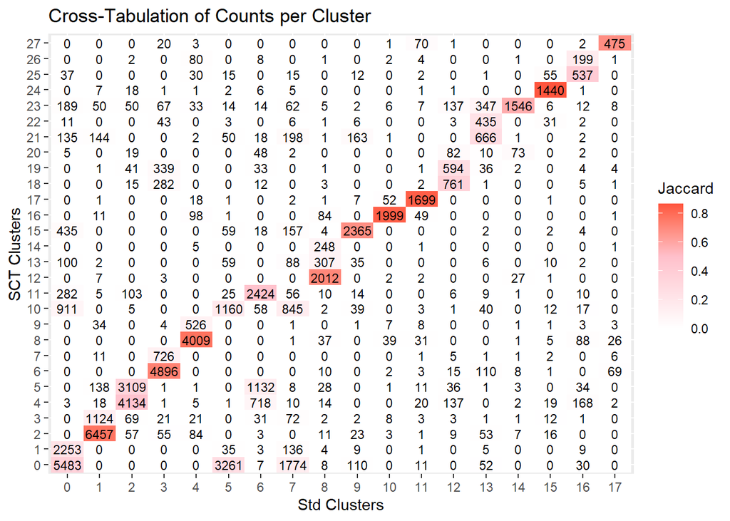

```r
x <- as.data.frame(table(spat$RNA_snn_res.0.5, spat$SCT_snn_res.0.5))

SCT_cluster <- c()
counts_ <- c()
for (i in unique(x$Var2)){
  temp <- x[x$Var2 == i,]
  cluster <- as.character(temp[which.max(temp$Freq),]$Var1)
  count <- temp[which.max(temp$Freq),]$Freq
  SCT_cluster <- c(SCT_cluster, cluster)
  counts_ <- c(counts_, count)
}

clusters <- data.frame(row.names = unique(x$Var2),
           counts = counts_,
           SCT_cluster = as.numeric(SCT_cluster))
clusters <- clusters[order(clusters$SCT_cluster, -clusters$counts),]
clusters$clusters <- 0:(dim(clusters)[1] -1)

# levels(spat$SCT_snn_res.0.5)
# clusters
spat$SCT_snn_res.0.5_renamed <- factor(spat$SCT_snn_res.0.5,
                                       labels = clusters[paste0(0:(dim(clusters)[1]-1)),]$clusters)
spat$SCT_snn_res.0.5_renamed <- factor(spat$SCT_snn_res.0.5_renamed,
                                       levels = 0:(dim(clusters)[1]-1))

x <- as.data.frame(table(spat$RNA_snn_res.0.5, spat$SCT_snn_res.0.5_renamed))


x$Var1.sum <- NA

for (i in unique(x$Var1)){
  x[x$Var1 == i,]$Var1.sum <- sum(x[x$Var1 == i,]$Freq)
}

x$Var2.sum <- NA

for (i in unique(x$Var2)){
  x[x$Var2 == i,]$Var2.sum <- sum(x[x$Var2 == i,]$Freq)
}

x$Var1.perc <- x$Freq / x$Var1.sum
x$Var2.perc <- x$Freq / x$Var2.sum

x$Jaccard <- x$Freq / (x$Var1.sum + x$Var2.sum - x$Freq)

ggplot(x, aes(x = Var1, y = Var2, label = Freq, fill = Jaccard)) +
  geom_tile() +
  xlab('Std Clusters') + ylab('SCT Clusters') +
  geom_text(size = 3) +
  scale_fill_gradient2(low = 'white', mid = "pink", high = 'red',
                       midpoint = .5) +
  ggtitle('Cross-Tabulation of Counts per Cluster')
```

```r
# ggplot(x, aes(x = Var1, y = Var2, label = round(Jaccard, 2),
#               fill = Jaccard)) +
#   geom_tile() +
#   xlab('Std Clusters') + ylab('SCT Clusters') +
#   geom_text(size = 3) +
#   scale_fill_gradient2(low = 'white', mid = "pink", high = 'red',
#                        midpoint = .5) +
#   ggtitle('Cross-Tabulation of Jaccard Index per Cluster')
```

### 8.1.3 Spat vs SCT

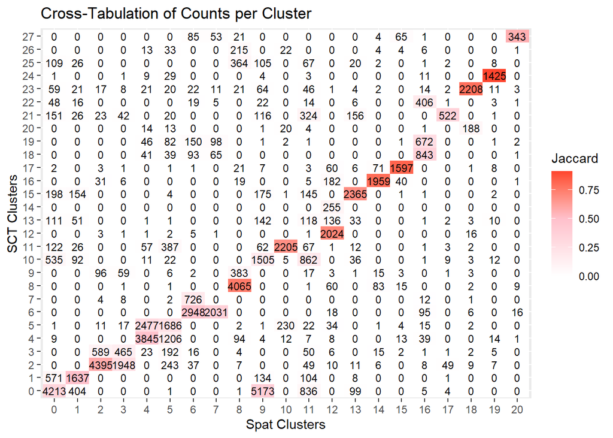

```r
x <- as.data.frame(table(spat$tpv_snn_res.0.5_renamed, spat$SCT_snn_res.0.5_renamed))


x$Var1.sum <- NA

for (i in unique(x$Var1)){
  x[x$Var1 == i,]$Var1.sum <- sum(x[x$Var1 == i,]$Freq)
}

x$Var2.sum <- NA

for (i in unique(x$Var2)){
  x[x$Var2 == i,]$Var2.sum <- sum(x[x$Var2 == i,]$Freq)
}

x$Var1.perc <- x$Freq / x$Var1.sum
x$Var2.perc <- x$Freq / x$Var2.sum

x$Jaccard <- x$Freq / (x$Var1.sum + x$Var2.sum - x$Freq)

ggplot(x, aes(x = Var1, y = Var2, label = Freq, fill = Jaccard)) +
  geom_tile() +
  xlab('Spat Clusters') + ylab('SCT Clusters') +
  geom_text(size = 3) +
  scale_fill_gradient2(low = 'white', mid = "pink", high = 'red',
                       midpoint = .5) +
  ggtitle('Cross-Tabulation of Counts per Cluster')
```

```r
#
# ggplot(x, aes(x = Var1, y = Var2, label = round(Jaccard, 2),
#               fill = Jaccard)) +
#   geom_tile() +
#   xlab('Spat Clusters') + ylab('SCT Clusters') +
#   geom_text(size = 3) +
#   scale_fill_gradient2(low = 'white', mid = "pink", high = 'red',
#                        midpoint = .5) +
#   ggtitle('Cross-Tabulation of Jaccard Index per Cluster')
```

### 8.1.4 Conclusions

For the most part we see a pretty overlapping occupancy of clusters (one-to-one correspondance, and the strong diagonal stripe).

## 8.2 Correlation

Here we will compare the cluster centroids by correlation (Pearson).

```r
cent <- list()
cent[['Std']] <- AverageExpression(spat,group.by = 'RNA_snn_res.0.5',
                                   assays = 'RNA', slot = 'scale.data')$RNA
cent[['tpv']] <- AverageExpression(spat,group.by = 'tpv_snn_res.0.5_renamed',
                                   assays = 'tpv', slot = 'scale.data')$tpv
cent[['sct']] <- AverageExpression(spat,group.by = 'SCT_snn_res.0.5_renamed',
                                   assays = 'SCT', slot = 'scale.data')$SCT

centroid_corr <- list()
centroid_corr[['Std_vs_tpv']] <- cor(cent[['Std']], cent[['tpv']], method = 'pearson')

centroid_corr[['Std_vs_sct']] <- cor(cent[['Std']], cent[['sct']], method = 'pearson')

centroid_corr[['tpv_vs_sct']] <- cor(cent[['tpv']], cent[['sct']], method = 'pearson')
```

### 8.2.1 Std vs Spat

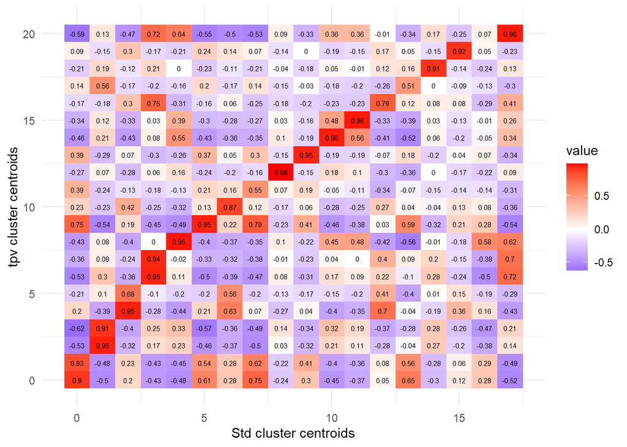

```r
i <- 1
name <- names(centroid_corr[i])

df <- centroid_corr[[i]]
df <- reshape2::melt(df)

x_name <- tstrsplit(name,'_',keep = 1)[[1]]
y_name <- tstrsplit(name,'_', keep = 3)[[1]]
# df
ggplot(df, aes(x = Var1, y = Var2, fill = value, label = round(value,2))) +
         geom_tile() +
         scale_fill_gradient2(low = 'blue', mid = 'white', high = 'red',
                              midpoint = mean(df$value)) +
  theme_minimal() +
  xlab(paste0(x_name, ' cluster centroids')) +
  ylab(paste0(y_name, ' cluster centroids')) +
  geom_text(size = 2)
```

### 8.2.2 Std vs SCT

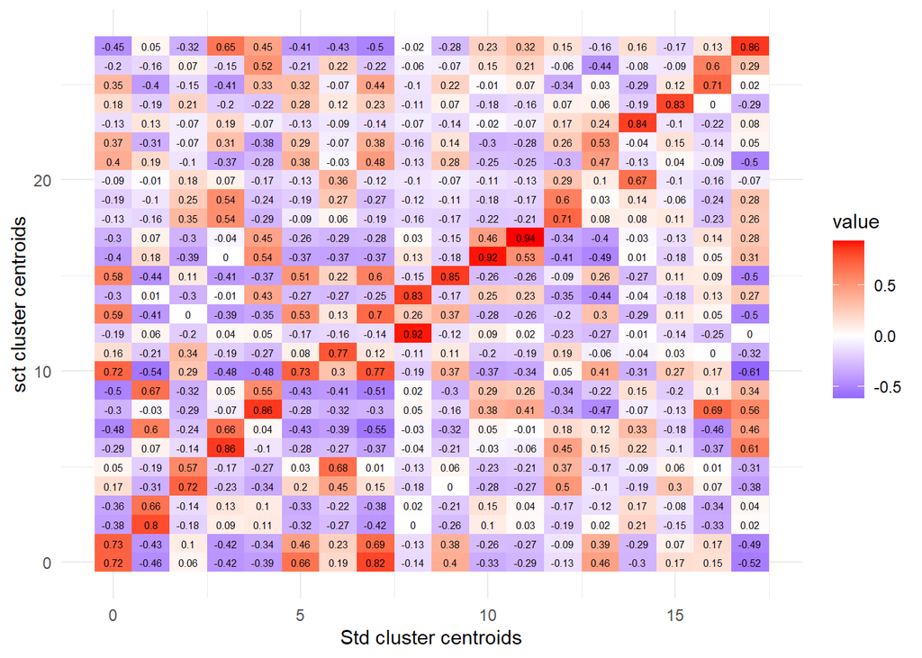

```r
i <- 2
name <- names(centroid_corr[i])

df <- centroid_corr[[i]]
df <- reshape2::melt(df)

x_name <- tstrsplit(name,'_',keep = 1)[[1]]
y_name <- tstrsplit(name,'_', keep = 3)[[1]]
# df
ggplot(df, aes(x = Var1, y = Var2, fill = value, label = round(value,2))) +
         geom_tile() +
         scale_fill_gradient2(low = 'blue', mid = 'white', high = 'red',
                              midpoint = mean(df$value)) +
  theme_minimal() +
  xlab(paste0(x_name, ' cluster centroids')) +
  ylab(paste0(y_name, ' cluster centroids')) +
  geom_text(size = 2)
```

### 8.2.3 Spat vs SCT

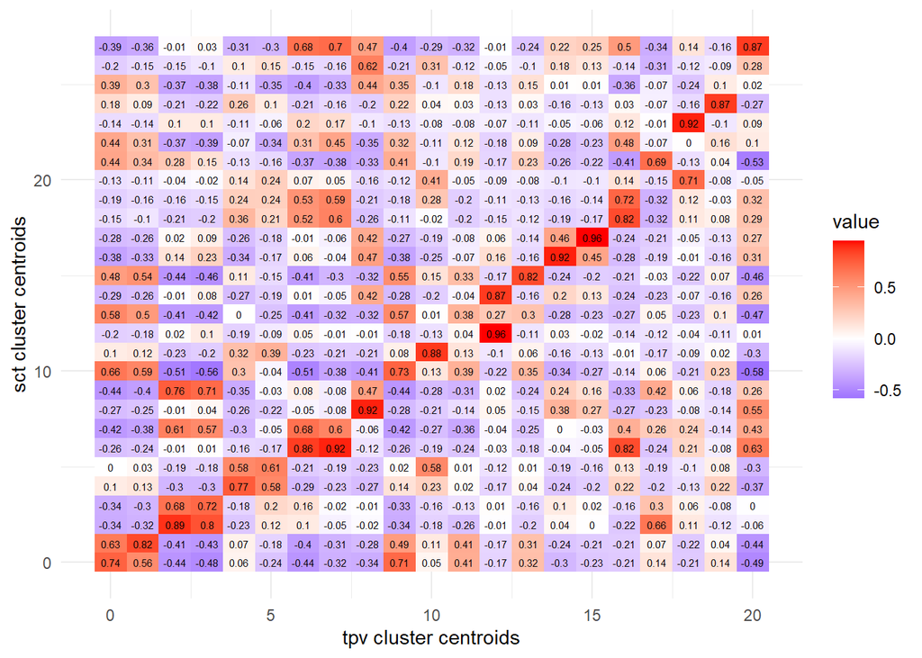

```r
i <- 3
name <- names(centroid_corr[i])

df <- centroid_corr[[i]]
df <- reshape2::melt(df)

x_name <- tstrsplit(name,'_',keep = 1)[[1]]
y_name <- tstrsplit(name,'_', keep = 3)[[1]]
# df
ggplot(df, aes(x = Var1, y = Var2, fill = value, label = round(value,2))) +
         geom_tile() +
         scale_fill_gradient2(low = 'blue', mid = 'white', high = 'red',
                              midpoint = mean(df$value)) +
  theme_minimal() +
  xlab(paste0(x_name, ' cluster centroids')) +
  ylab(paste0(y_name, ' cluster centroids')) +
  geom_text(size = 2)
```

### 8.2.4 Conclusions

It may come as no surprise since this is a similar analysis but the results of the cluster correlations close resembles the results for the cross-tabulation of clusters. Once again we see general correspondence between the three methods.

# 9 SessionInfo

```r
# saveRDS(spat, '/Users/DouglasHannumJr/Desktop/s3_bucket_data/s3_bucket_data/spat.Rds')
# spat <- readRDS('/Users/DouglasHannumJr/Desktop/s3_bucket_data/s3_bucket_data/spat.Rds')
```